# Exploratory Data Analysis - Red Wine Quality

by Tim Roberts

## Table of Contents

1. Initial Analysis
2. Univariate Exploration
3. Bivaiate Exploration
4. MultiVariate Exploration
5. Final Plots
6. Reflection

**Dataset**: a data set from 2009 testing the chemical properties of the Portuguese “Vinho Verde” red wine variant. At least 3 wine experts rated the quality of each wine between 0 (very bad) and 10 (very excellent). More information can be found [here.](https://s3.amazonaws.com/udacity-hosted-downloads/ud651/wineQualityInfo.txt).

**Question**: What variables contribute to making the best quality Red Wine?

# 1. Initial Analysis: structure of the dataset.

In this section, I will first look at the structure of the data set. Then I will examine the distribution of each attribute individually by plotting its distribution.

**List of Variables**

```
##  [1] "fixed.acidity"        "volatile.acidity"     "citric.acid"
##  [4] "residual.sugar"       "chlorides"            "free.sulfur.dioxide"
##  [7] "total.sulfur.dioxide" "density"              "pH"
## [10] "sulphates"            "alcohol"              "quality"
```

### Field Descriptions:

1. **Fixed acidity**: most wine acids involved are fixed or nonvolatile. (do not evaporate readily)
2. **Volatile acidity**: amount of acetic acid in wine - can be unpleasant, vinegary taste if too high?
3. **Citric acid**: found in small quantities, can add ‘freshness’ and flavor to wines.
4. **Residual sugar**: sugar remaining after fermentation stops, rare < 1 gram/liter, > 45 grams/liter are considered sweet.
5. **Chlorides**: amount of salt in the wine.
6. **Free sulfur dioxide**: the free form of SO2 - prevents microbial growth and the oxidation of wine.
7. **Total sulfur dioxide**: free + bound forms of S02; in low concentrations, mostly undetectable in wine, free SO2 over 50 ppm, evident in the nose and taste of wine.
8. **Density**: the density of water is close to that of water (approx 1) depending on the percent alcohol and sugar content.
9. **pH**: acidic on a scale from 0 (very acidic) to 14 (very basic); most wines are between 3-4 on the pH scale.
10. **Sulphates**: anadditive which can contribute to S02 levels, acts as an antimicrobial and antioxidant.
11. **Alcohol**: the percent alcohol content of the wine.
12. **Quality (Output Variable)** - sensory score between 0 and 10.

**Data Structure**

```
## 'data.frame':    1599 obs. of  12 variables:
##  $ fixed.acidity       : num  7.4 7.8 7.8 11.2 7.4 7.4 7.9 7.3 7.8 7.5 ...
##  $ volatile.acidity    : num  0.7 0.88 0.76 0.28 0.7 0.66 0.6 0.65 0.58 0.5 ...
##  $ citric.acid         : num  0 0 0.04 0.56 0 0 0.06 0 0.02 0.36 ...
##  $ residual.sugar      : num  1.9 2.6 2.3 1.9 1.9 1.8 1.6 1.2 2 6.1 ...
##  $ chlorides           : num  0.076 0.098 0.092 0.075 0.076 0.075 0.069 0.065 0.073 0.071 ...
##  $ free.sulfur.dioxide : num  11 25 15 17 11 13 15 15 9 17 ...
##  $ total.sulfur.dioxide: num  34 67 54 60 34 40 59 21 18 102 ...
##  $ density             : num  0.998 0.997 0.997 0.998 0.998 ...
##  $ pH                  : num  3.51 3.2 3.26 3.16 3.51 3.51 3.3 3.39 3.36 3.35 ...
##  $ sulphates           : num  0.56 0.68 0.65 0.58 0.56 0.56 0.46 0.47 0.57 0.8 ...
##  $ alcohol             : num  9.4 9.8 9.8 9.8 9.4 9.4 9.4 10 9.5 10.5 ...
##  $ quality             : int  5 5 5 6 5 5 5 7 7 5 ...
```

The red wine dataset contains 12 variables. There are 11 input numerical variables based on physicochemical tests and 1 categorical output variable (quality) based on sensory data, with 1599 observations.

**All Descriptive Stats**

```
##  fixed.acidity   volatile.acidity  citric.acid    residual.sugar
##  Min.   : 4.60   Min.   :0.1200   Min.   :0.000   Min.   : 0.900
##  1st Qu.: 7.10   1st Qu.:0.3900   1st Qu.:0.090   1st Qu.: 1.900
##  Median : 7.90   Median :0.5200   Median :0.260   Median : 2.200
##  Mean   : 8.32   Mean   :0.5278   Mean   :0.271   Mean   : 2.539
##  3rd Qu.: 9.20   3rd Qu.:0.6400   3rd Qu.:0.420   3rd Qu.: 2.600
##  Max.   :15.90   Max.   :1.5800   Max.   :1.000   Max.   :15.500
##    chlorides       free.sulfur.dioxide total.sulfur.dioxide    density
##  Min.   :0.01200   Min.   : 1.00       Min.   :  6.00       Min.   :0.9901
##  1st Qu.:0.07000   1st Qu.: 7.00       1st Qu.: 22.00       1st Qu.:0.9956
##  Median :0.07900   Median :14.00       Median : 38.00       Median :0.9968
##  Mean   :0.08747   Mean   :15.87       Mean   : 46.47       Mean   :0.9967
##  3rd Qu.:0.09000   3rd Qu.:21.00       3rd Qu.: 62.00       3rd Qu.:0.9978
##  Max.   :0.61100   Max.   :72.00       Max.   :289.00       Max.   :1.0037
##        pH          sulphates         alcohol         quality
##  Min.   :2.740   Min.   :0.3300   Min.   : 8.40   Min.   :3.000
##  1st Qu.:3.210   1st Qu.:0.5500   1st Qu.: 9.50   1st Qu.:5.000
##  Median :3.310   Median :0.6200   Median :10.20   Median :6.000
##  Mean   :3.311   Mean   :0.6581   Mean   :10.42   Mean   :5.636
##  3rd Qu.:3.400   3rd Qu.:0.7300   3rd Qu.:11.10   3rd Qu.:6.000
##  Max.   :4.010   Max.   :2.0000   Max.   :14.90   Max.   :8.000
```

**Quality Table**

```
##
##   3   4   5   6   7   8
##  10  53 681 638 199  18
```

# 2. Univariate Exploration

**Fixed acidity**

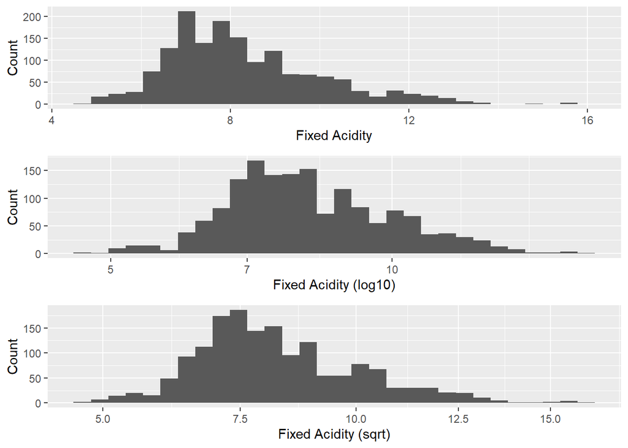

Distribution looks better using log10 transformation but it is long-tailed.

Quality Table: Fixed Acidity > 14

```
##
##     FALSE TRUE
##   3    10    0
##   4    53    0
##   5   677    4
##   6   637    1
##   7   196    3
##   8    18    0
```

A few outliers can be seen in the table above for Fixed acidity > 14.

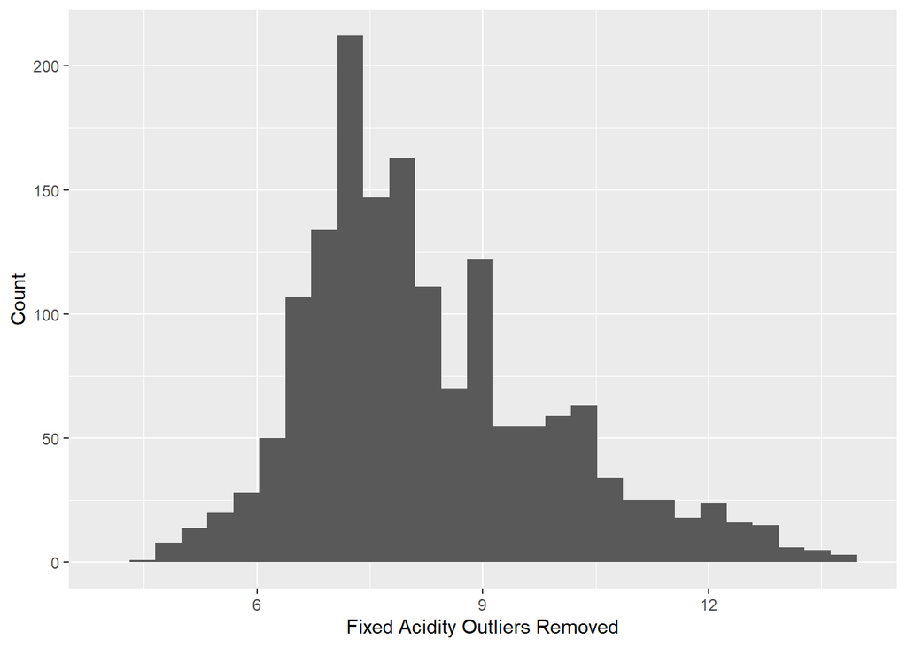

Distribution looks best using log10 transformation with outliers (> 14) removed.

**Volatile Acidity**

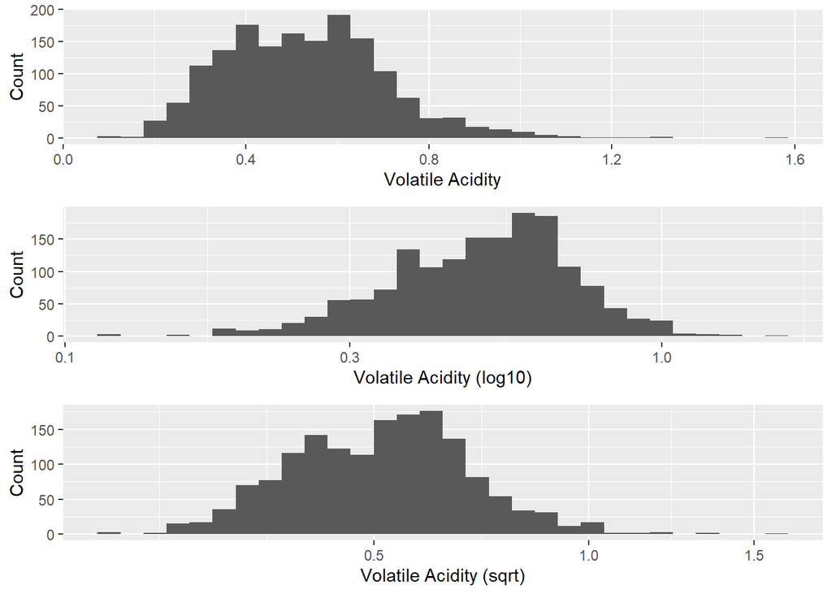

Quality Table: Volatile Acidity > 1.2

```
##
##     FALSE TRUE
##   3     9    1
##   4    53    0
##   5   678    3
##   6   638    0
##   7   199    0
##   8    18    0
```

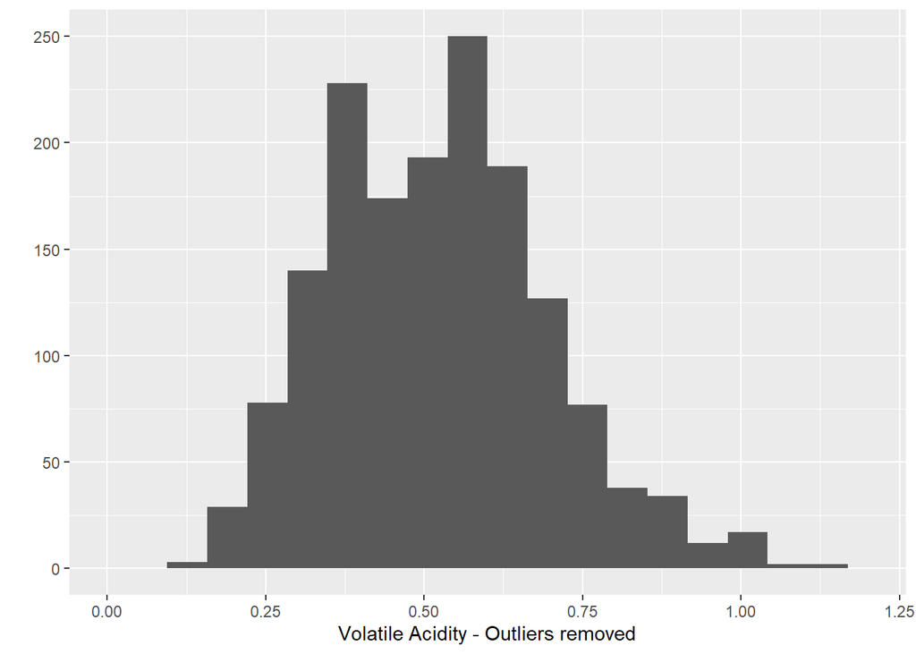

The best option seemed to be to used a sqrt transformation and remove 4 outliers (>1.2)

**Citric Acid**

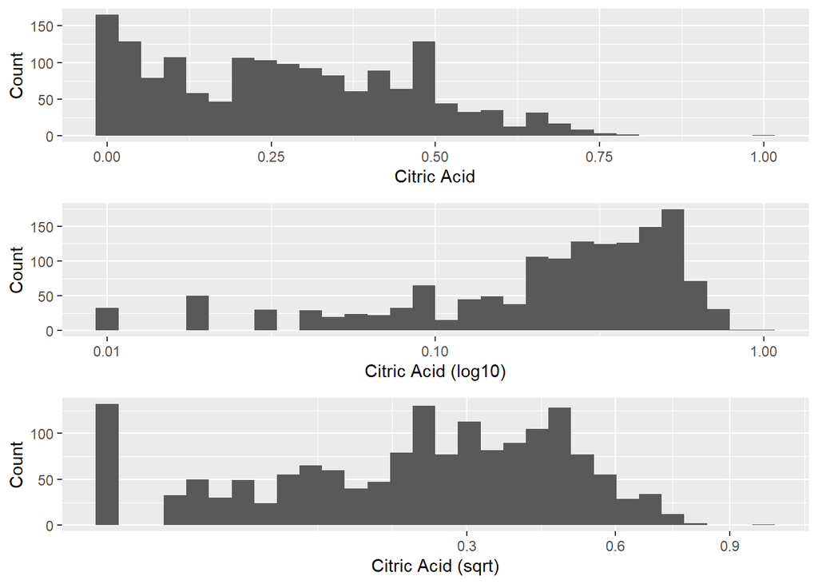

Quality Table: Citric Acid == 0

```
##
##     FALSE TRUE
##   3     7    3
##   4    43   10
##   5   624   57
##   6   584   54
##   7   191    8
##   8    18    0
```

Quality Table: Citric Acid > 0.75

```
##
##     FALSE TRUE
##   3    10    0
##   4    52    1
##   5   679    2
##   6   637    1
##   7   197    2
##   8    18    0
```

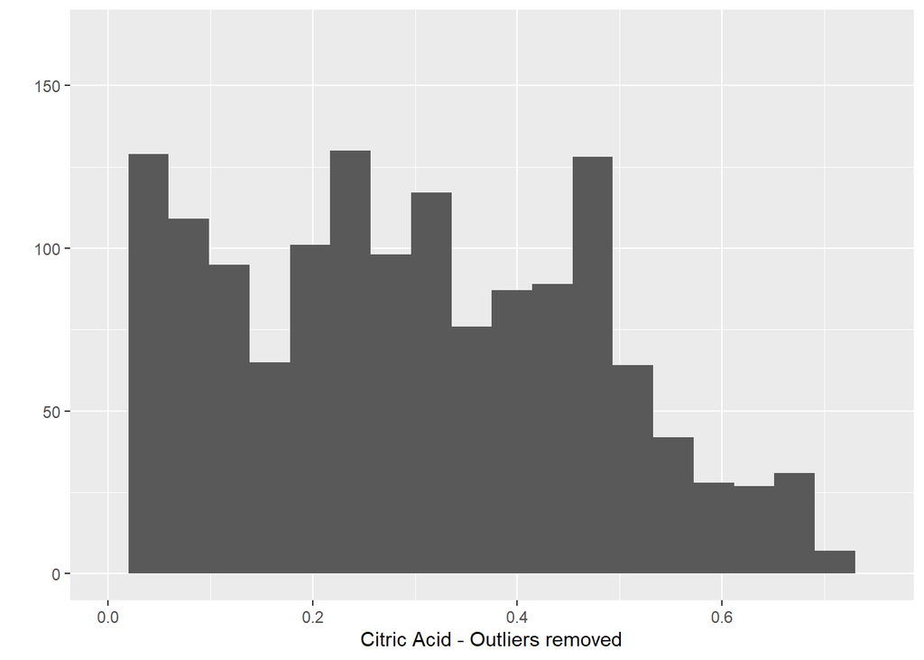

There are 132 0 values which seem to be pretty evenly distributed on quality. None of the transformations seem suitable. The best that can be done is to remove 6 outliers which spreads the distribution out.

**Residual Sugar**

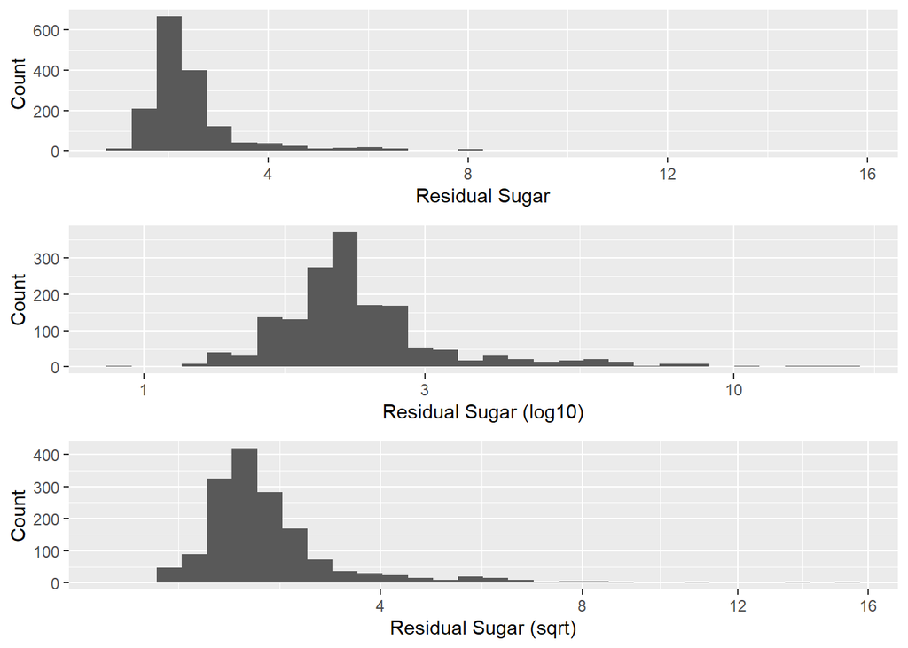

Quality Table: Residual Sugar > 6

```
##
##     FALSE TRUE
##   3    10    0
##   4    51    2
##   5   658   23
##   6   624   14
##   7   191    8
##   8    17    1
```

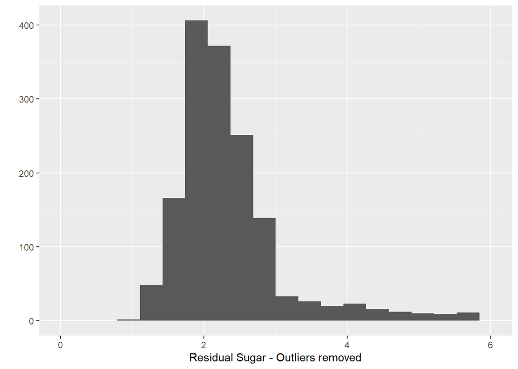

**Chlorides**

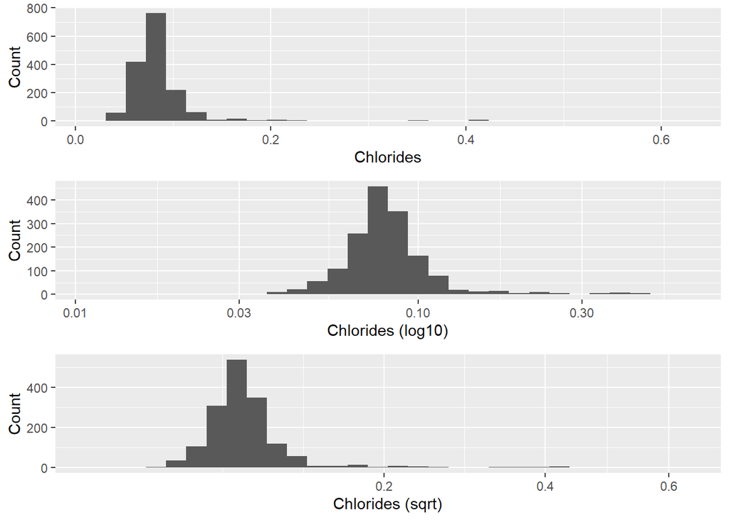

Quality Table: Chlorides > .2

[output not shown]

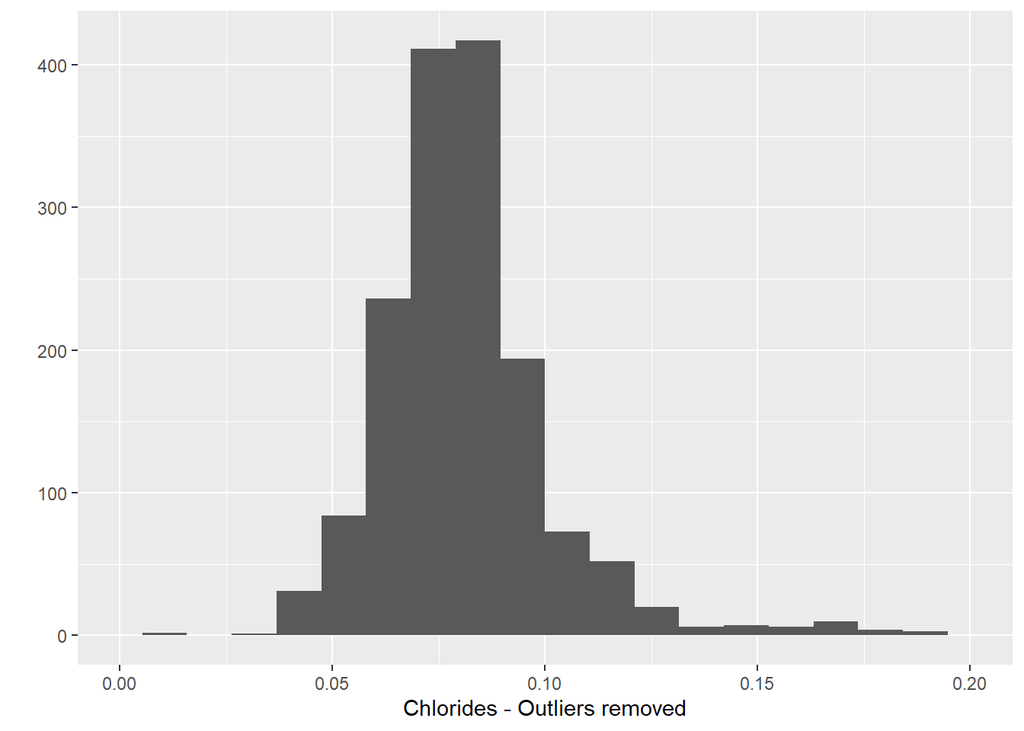

For chlorides the log10 transformation produced a central relatively evenly spread curve.

**Free Sulfur Dioxide**

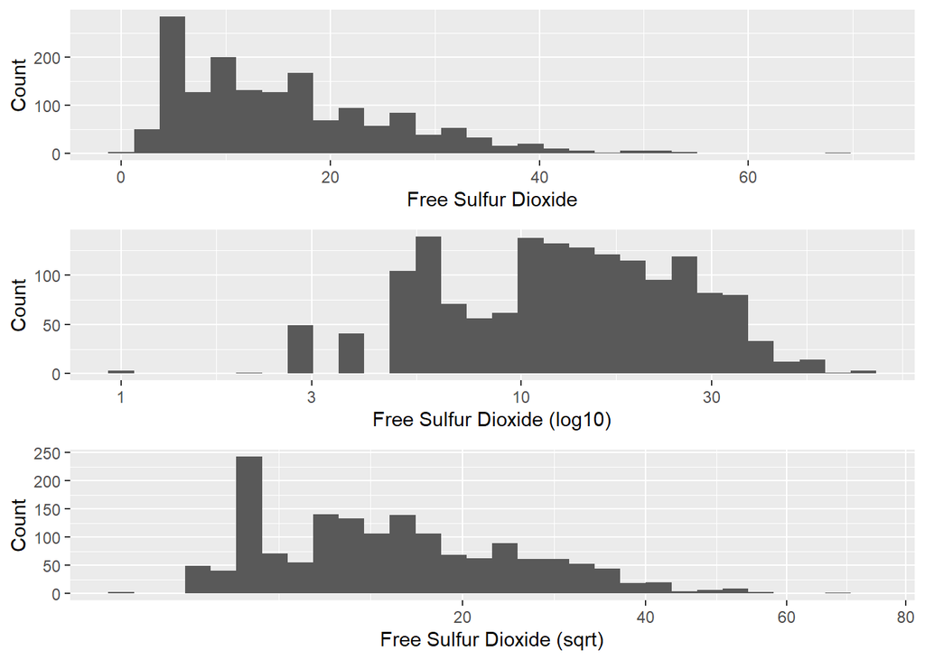

Quality Table: Free Sulfur Dioxide > 60

```
##
##     FALSE TRUE
##   3    10    0
##   4    53    0
##   5   678    3
##   6   637    1
##   7   199    0
##   8    18    0
```

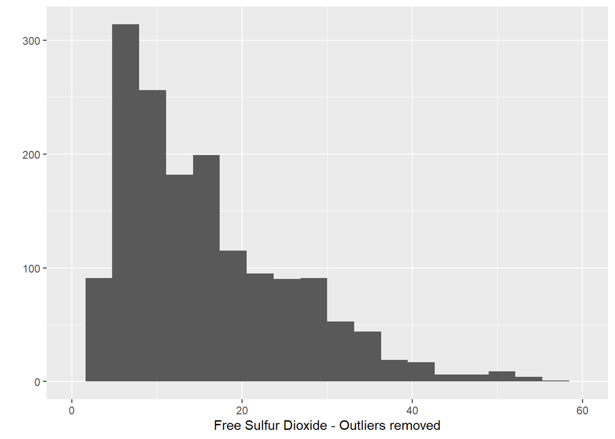

The sqrt transformation was used as this normalises better than log 10. Removing 4 outliers doesn’t alter the distribution significantly.

**Total Sulfur Dioxide**

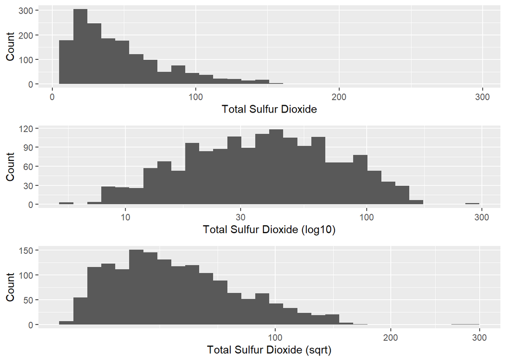

Quality Table: Total Sulfur Dioxide > 160

```
##
##     FALSE TRUE
##   3    10    0
##   4    53    0
##   5   681    0
##   6   637    1
##   7   197    2
##   8    18    0
```

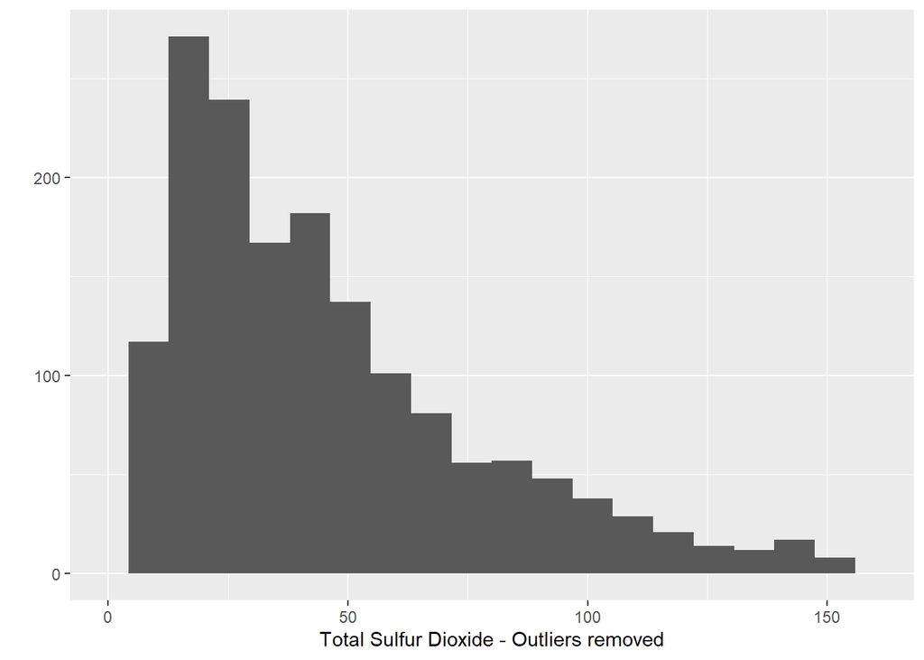

Removed 3 outliers for total sulfur dioxide (>160). The distribution is still heavily positively skewed but neither transformation option seems to have a significant effect.

**Density**

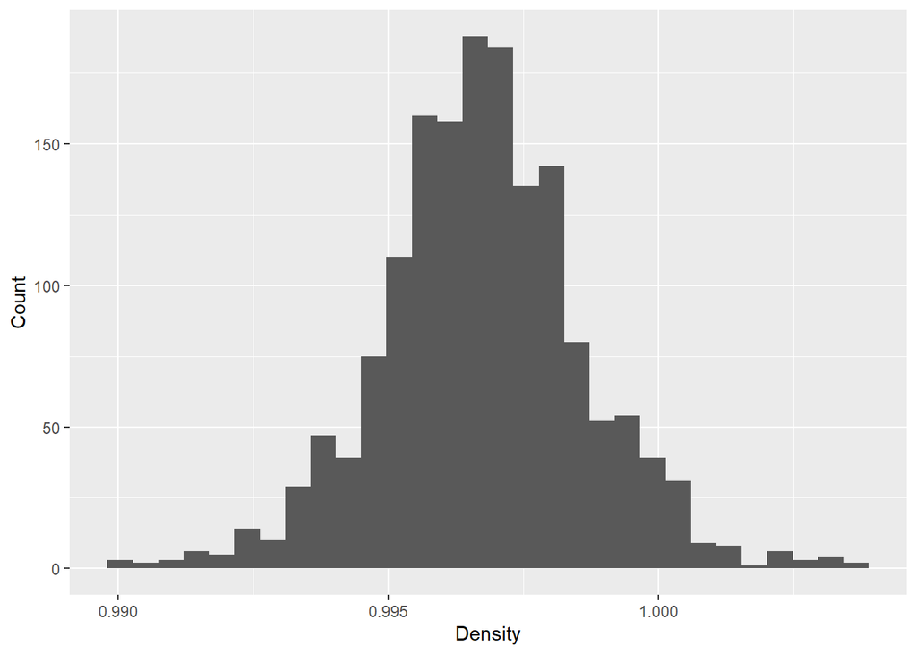

No change - normal already

**pH**

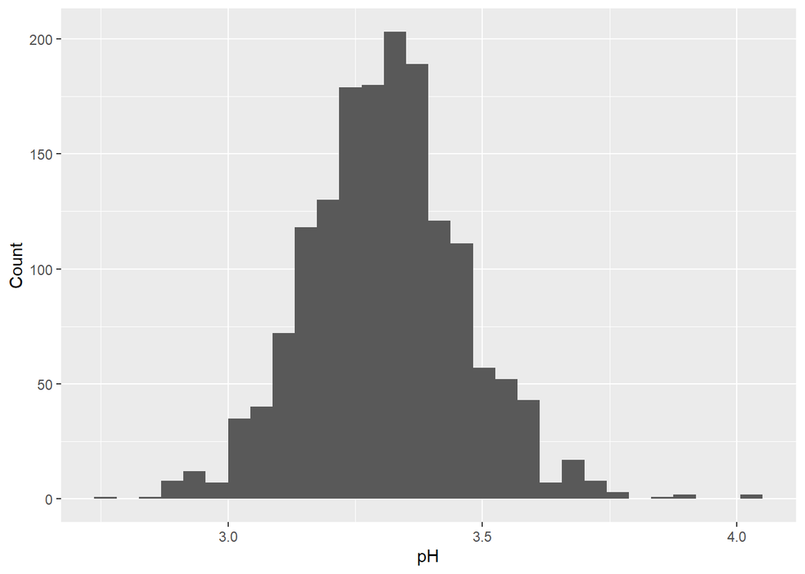

No change - normal already

**Sulphates**

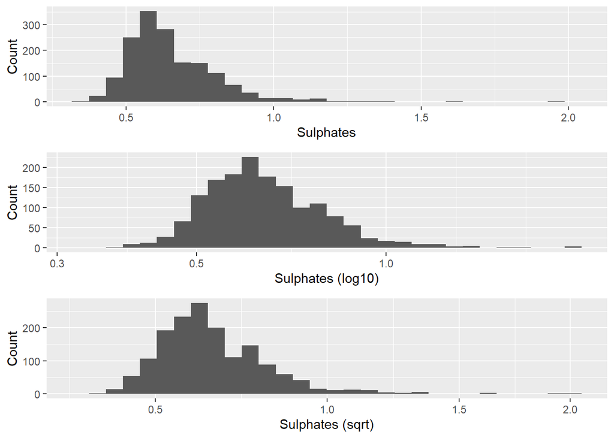

Quality Table: Sulphates > 1.5

```
##
##     FALSE TRUE
##   3    10    0
##   4    52    1
##   5   677    4
##   6   635    3
##   7   199    0
##   8    18    0
```

**Alcohol**

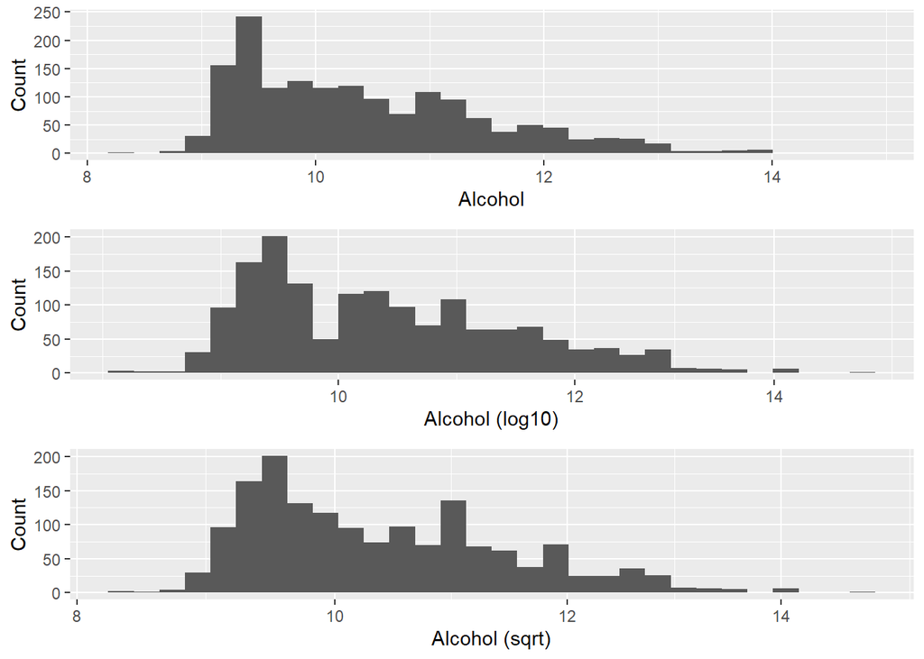

Quality Table: Alcohol > 14

```
##
##     FALSE TRUE
##   3    10    0
##   4    53    0
##   5   680    1
##   6   638    0
##   7   199    0
##   8    18    0
```

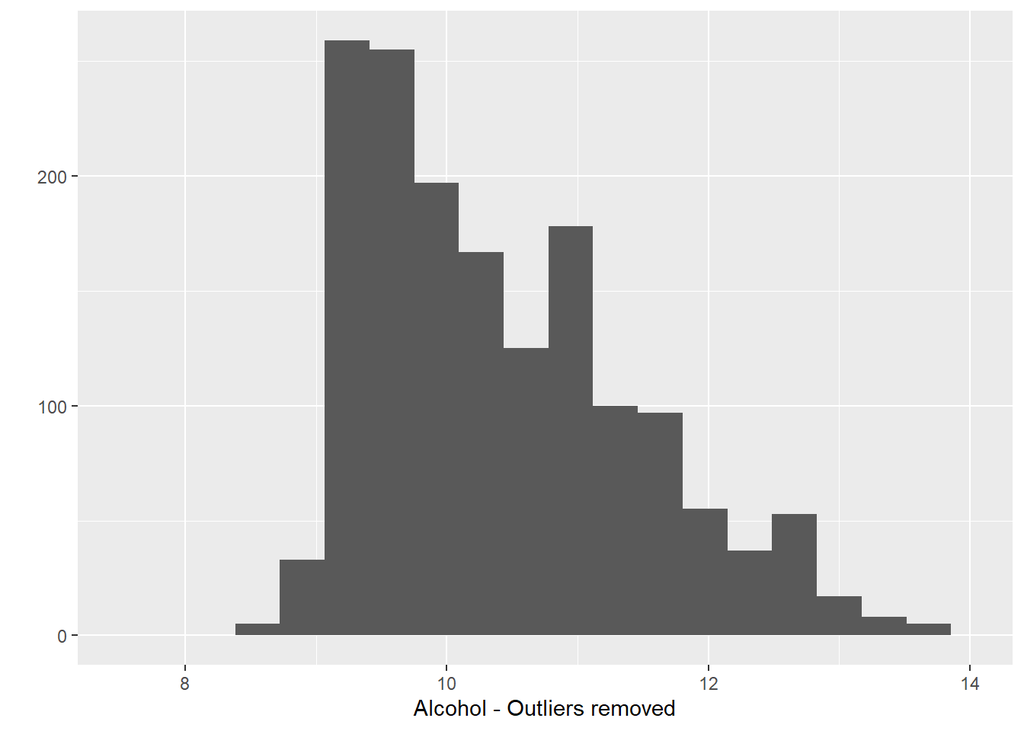

**Wine Quality**

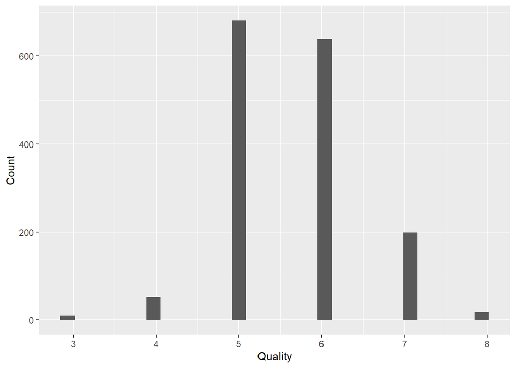

Looking at the first plot of wine quality, it roughly has a normal distribution with most rating being in 5 and 6. Will create another variable called rating with following categories.

- 0-4 : poor
- 5-6: average
- 7-10 : good

```
##    poor average    good
##      63    1319     217
```

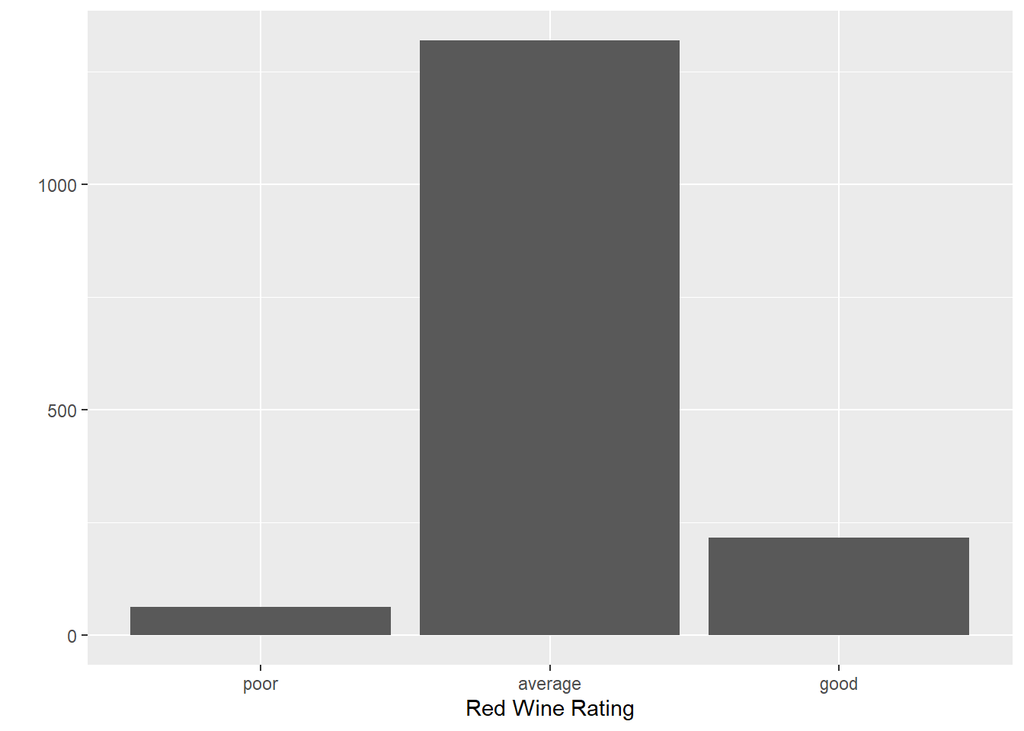

### Univariate Analysis

**What is the structure of your dataset?**

There are 12 attributes in the dataset. 11 of them (fixed acidity, volatile acidity, citric acid, residual sugar, chlorides, free sulfur dioxide, total sulfur dioxide, density, pH, sulphates, alcohol) are input attributes based on physicochemical tests. The other attribute (quality) is the output attribute based on sensory data. Each row corresponds to one particular wine with total 1599 different red wines in the data set.

**What is/are the main feature(s) of interest in your dataset?**

The main feature of interest is the output attribute quality. I want to find out which of the 11 input attributes contribute to a high quality value.

**What other features in the dataset do you think will help support your investigation into your feature(s) of interest?**

The 11 input attributes are equally likely to contribute to the quality value at this point. The bivariate exploration will look more closely at how each of the attributes is distributed with a given quality value.

**Did you create any new variables from existing variables in the dataset?**

Yes I created a rating variable to rate wines as poor, average or good.

**Of the features you investigated, were there any unusual distributions? Did you perform any operations on the data to tidy, adjust, or change the form of the data? If so, why did you do this?**

Yes there are some distributions that are unusual. I adjusted these plots by taking log10 or sqrt values for the plots where appropriate because more accurate trends can be inferred from bivarite plots.

# 3. Bivaiate Exploration

**Correlation of variables**

Correlation of variables against quality is calculated to further explore.

```
##   log10.fixed.acidity sqrt.volatile.acidity      sqrt.citric.acid
##            0.11423756           -0.39394603            0.20668220
##  log10.residual.sugar       log10.chlordies         sqrt.free.S02
##            0.02353331           -0.17613996           -0.05147378
##        sqrt.total.S02               density                    pH
##           -0.18419180           -0.17491923           -0.05773139
##       log10.sulphates          sqrt.alcohol
##            0.30864193            0.47682047
```

**Positive Correlations**

Alcohol Content has biggest correlation value to wine quality, so lets start with a basic scatter plot of the both.

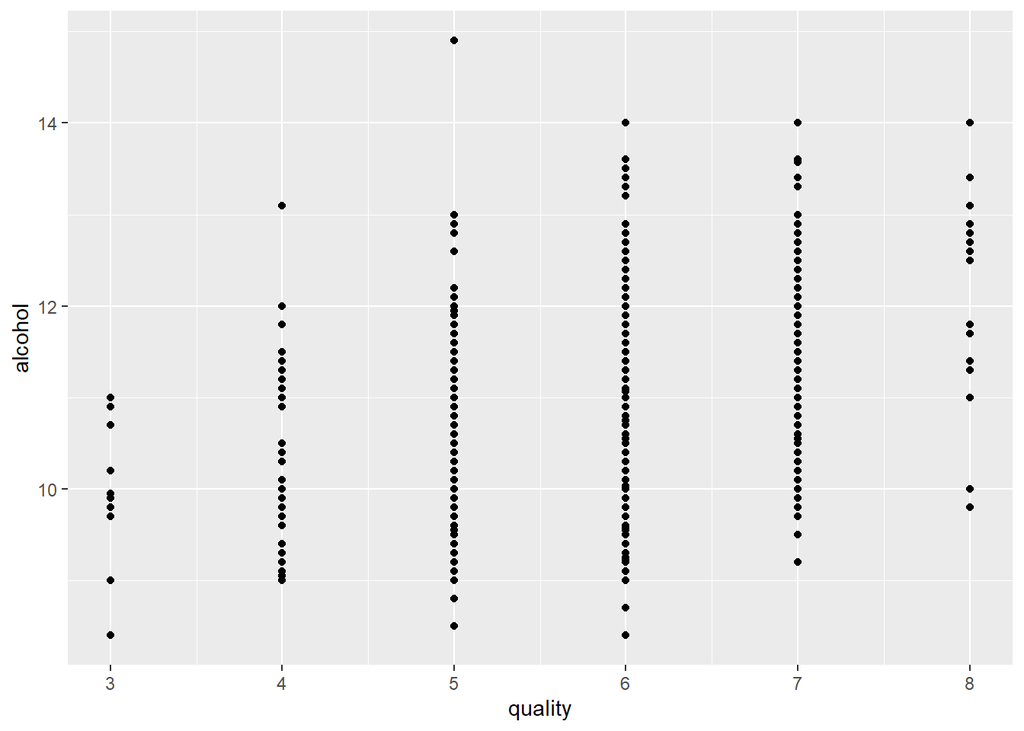

Original plot is over-crowded will add alpha values and jitter with trend line to observe the general trend.

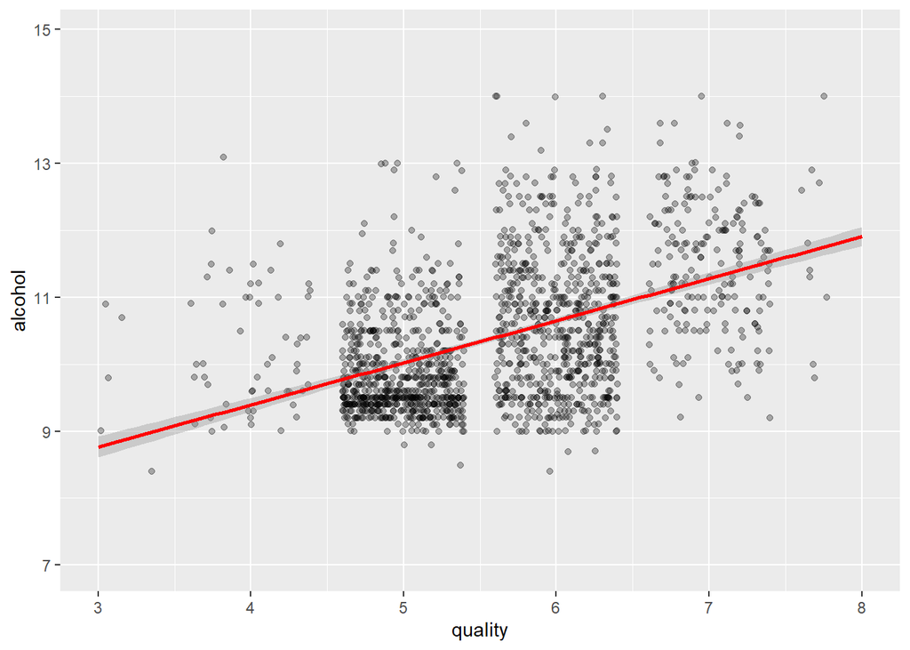

Next will look at sulfates.

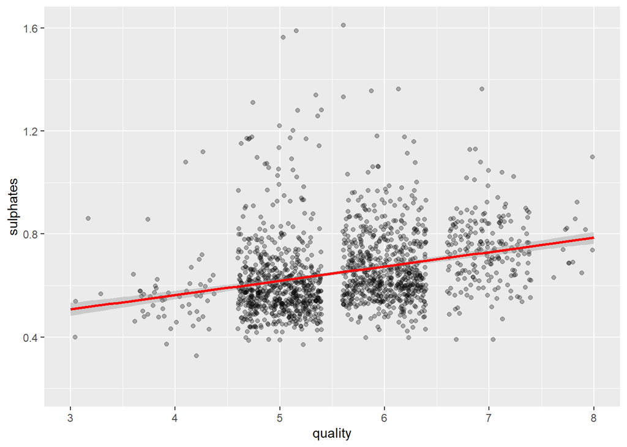

Citric Acid.

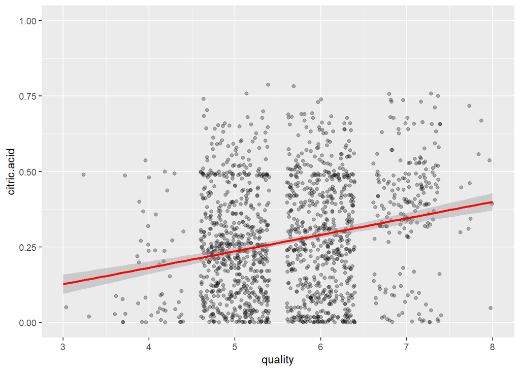

Fixed Acidity.

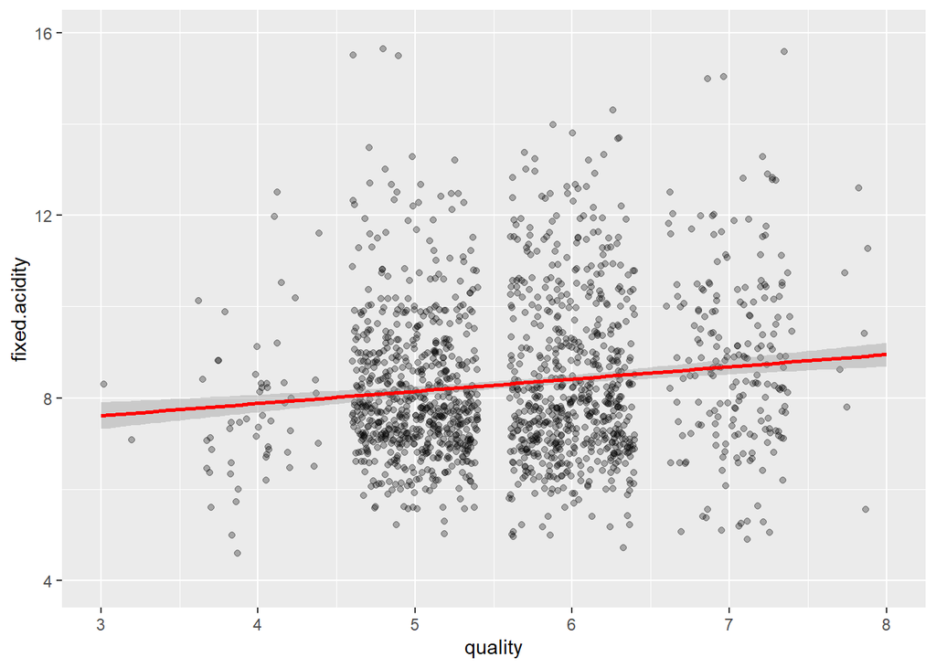

**Negative Correlations**

Density.

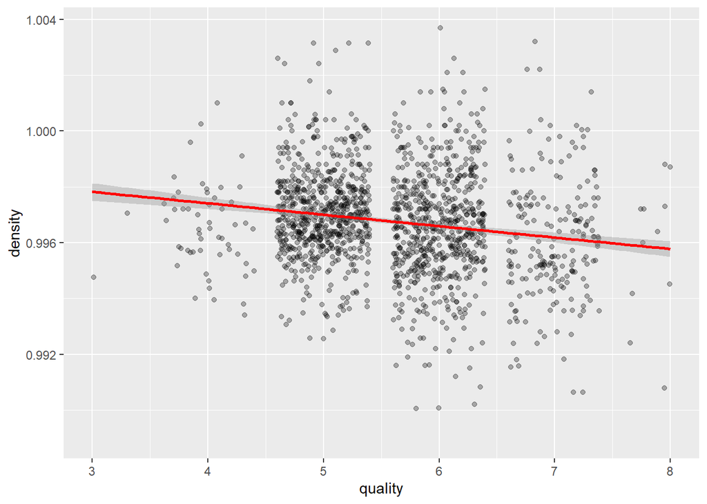

Chlorides.

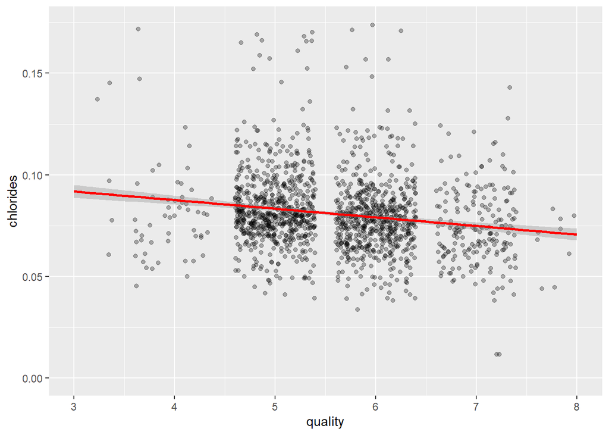

Total Sulfur Dioxide.

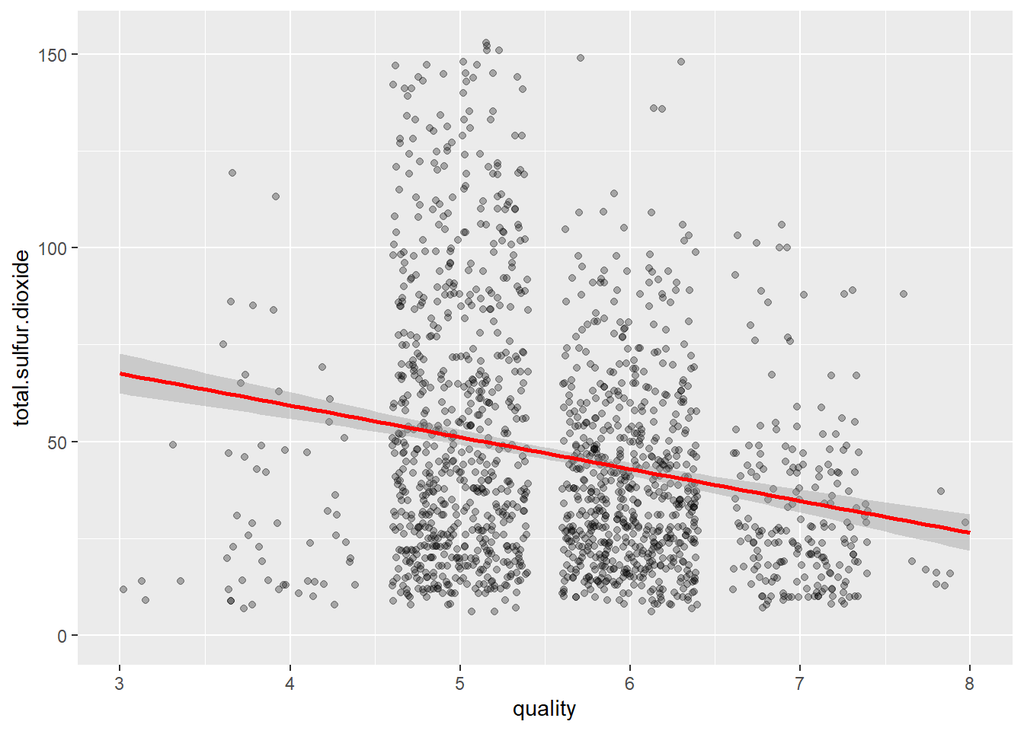

Volatile Acidity.

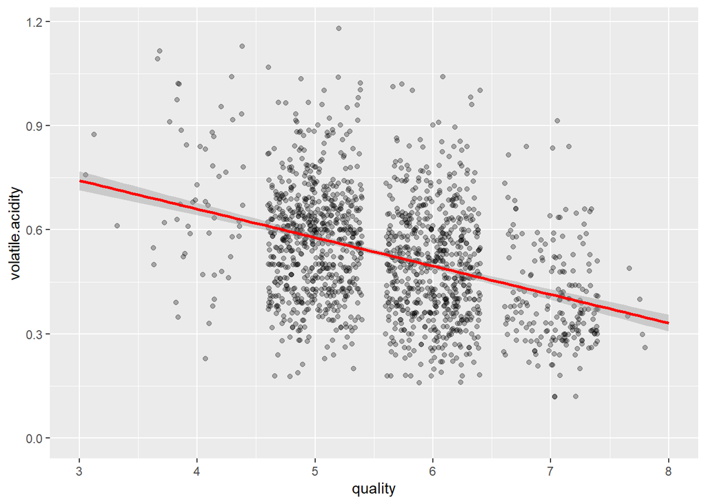